# Tarea 14 - Distribucion Normal

Brigido Vicuna

9/15/2020

La cantidad de tiempo (en horas) utilizada para completar un producto determinado sigue una distribución N(10, 2) . Calculad la probabilidad de que se tarde: a) Menos de 6 horas

2. Entre 7 y 13 horas

Estandarizad y luego calculad la probabilidad requerida mediante las tablas y comprobad vuestro resultado en R (o Python)

```r
m = 10
sigma = 2

round(pnorm(6, m, sigma)*100,2)
```

```
## [1] 2.28
```

```r
#La probabilidad de que se tarde menos de 6 horas es 2.27%


round(pnorm(13, m, sigma)*100 - pnorm(7, 10, 2)*100,2)
```

```
## [1] 86.64
```

```r
#La probabilidad de que se tarde entre 7 y 13 horas es 86.63%
```

```r
#Estandarizacion para menos de 6 horas.
z = (6-m)/sigma
z
```

```
## [1] -2
```

```r
#Para z = 2, la probabilidad es 2.28%

#Estandarizacion entre 7 y 13 horas.
z = (7-m)/sigma
z
```

```
## [1] -1.5
```

```r
z = (13-m)/sigma
z
```

```
## [1] 1.5
```

```r
#Para z = 1.5, la probabilidad es 93.32% mientras que apra z = -1.5 la probabilidad es 6.68%.
#Por lo tanto, la probabilidad para z<= 1.5 - z<= -1.5 es 93.32 - 6.68.

p_7_13 = 93.32 - 6.68
p_7_13
```

```
## [1] 86.64
```

El valor (en millones) de las ventas anuales realizadas en la Discográfica “Hasta quedarnos sin tímpanos” sigue un modelo normal de media igual a 200 y desviación tíıpica igual a 40.

1. Calcula la probabilidad de que el número de ventas sea exactamente igual a 200 (millones)
2. Calcula la probabilidad de que el número de ventas sea mayor que 250 (millones)
3. Calcula la probabilidad de que el número de ventas sea menor o igual que 100 (millones)

Estandarizad y luego calculad la probabilidad requerida mediante las tablas y comprobad vuestro resultado en R (o Python)

```r
m2 = 200000000
sigma2 = 40000000

#Ventas exactamente igual a 200 (millones)

#La probabilidad es cero ya que se trata de una variable aleatoria continua.

#Ventas mayor que 250 (millones)

(1 - pnorm(250000000,m2,sigma2))*100
```

```
## [1] 10.56498
```

```r
#Ventas menor o igual que 100 (millones)

pnorm(100000000,m2,sigma2)*100
```

```
## [1] 0.6209665
```

```r
#Estandarizacion.

#Ventas exactamente igual a 200 (millones)
#La probabilidad es cero ya que se trata de una variable aleatoria continua.


#Ventas mayor que 250 (millones)
z = (250000000-m2)/sigma2
z
```

```
## [1] 1.25
```

```r
#Para z = 1.25 la probabilidad es 89.44%, por lo tanto la probabilidad de que el numero de ventas sea
#mayor que 250 millones es 100% - 89.44%

p = 100-89.44
p
```

```
## [1] 10.56
```

```r
#Ventas menor o igual que 100 (millones)
z = (100000000-m2)/sigma2
z
```

```
## [1] -2.5
```

```r
#Para z = -2.5, la probabilidad es 0.62%
```

Las puntuaciones obtenidas en un examen tipo test realizado a un grupo de opositores se distribuyen normalmente con media 50 y desviación típica 6.5. Calculad

1. Probabilidad de tener una puntuación menor a 23 puntos.
2. Probabilidad de tener entre 27.3 y 43.1 puntos
3. Probabilidad de tener más de 62 puntos
4. Probabilidad de tener 3.2 puntos o menos
5. Hallad el número de puntos que se deben obtener para que la probabilidad de sacar menos de esa cantidad de puntos sea de 0.045
6. Repetid el apartado anterior, pero esta vez para obtener una probabilidad de 0.45

Estandarizad y luego calculad la probabilidad requerida mediante las tablas y comprobad vuestro resultado en R (o Python)

```r
m3 = 50
sigma3 = 6.5

#a) Probabilidad de tener una puntuación menor a 23 puntos.
pnorm(23,m3,sigma3)*100
```

```
## [1] 0.001634665
```

```r
#b) Probabilidad de tener entre 27.3 y 43.1 puntos
pnorm(43.1,m3,sigma3)*100 - pnorm(27.3,m3,sigma3)*100
```

```
## [1] 14.39832
```

```r
#c) Probabilidad de tener más de 62 puntos
100 - pnorm(62,m3,sigma3)*100
```

```
## [1] 3.243494
```

```r
#d) Probabilidad de tener 3.2 puntos o menos
pnorm(3.2,m3,sigma3)*100
```

```
## [1] 3.010628e-11
```

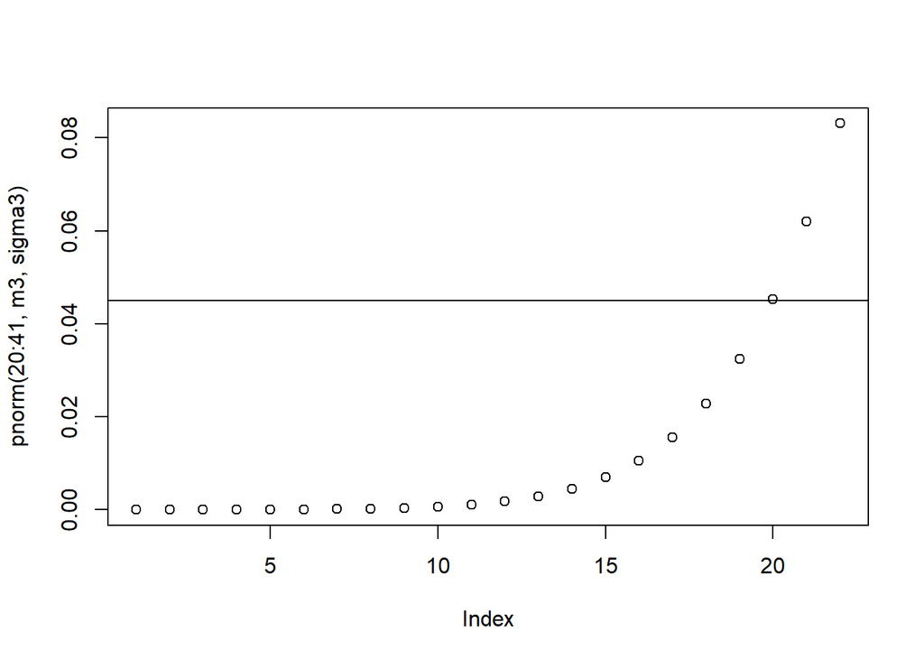

```r
#e) Hallad el número de puntos que se deben obtener para que la probabilidad de sacar menos de esa cantidad de puntos sea de 0.045
plot(pnorm(20:41,m3,sigma3))
abline(h=0.045)
```

```r
pnorm(39,m3,sigma3)
```

```
## [1] 0.04529366
```